# Western Biodiversity Inventory - Exploration

Adminon Kusack

2024-03-05

```r
library(tidyverse)
library(rinat)
library(jsonlite)
library(ggplot2)

source("C:/Users/Admin/Documents/GitHub/Western-Biodiversity-Inventory_rinat/R/get_inat_user_stats_v2.R") # Modified function to allow for month specific queries
source("C:/Users/Admin/Documents/GitHub/iNatTools/R/iNat_sc.R") # Modified function to fix error in code (forked from iNatTools main)
```

## Observation Data

First we can download observation data for the Biodiversity Inventory at Western. This step can be run each time the code is run, but the processing time/download time is high, so by default it will only download the data if knit with the correct parameters. This saves a dataframe, locally, that contains all of the observations for the project. If the number of observations ever goes above 10,000 the code will need to modified to download subsets separately as the maximum number of downloads using the API is 10,000. In that case, using the **get_inat_obs(…)** function would be easier.

```r
observations <- get_inat_obs(place_id = 142216, month = 1, maxresults = 10000)
observations <- rbind(get_inat_obs(place_id = 142216, month = 2, maxresults = 10000), observations)
observations <- rbind(get_inat_obs(place_id = 142216, month = 3, maxresults = 10000), observations)
observations <- rbind(get_inat_obs(place_id = 142216, month = 4, maxresults = 10000), observations)
observations <- rbind(get_inat_obs(place_id = 142216, month = 5, maxresults = 10000), observations)
observations <- rbind(get_inat_obs(place_id = 142216, month = 6, maxresults = 10000), observations)
observations <- rbind(get_inat_obs(place_id = 142216, month = 7, maxresults = 10000), observations)
observations <- rbind(get_inat_obs(place_id = 142216, month = 8, maxresults = 10000), observations)
observations <- rbind(get_inat_obs(place_id = 142216, month = 9, maxresults = 10000), observations)
observations <- rbind(get_inat_obs(place_id = 142216, month = 10, maxresults = 10000), observations)
observations <- rbind(get_inat_obs(place_id = 142216, month = 11, maxresults = 10000), observations)
observations <- rbind(get_inat_obs(place_id = 142216, month = 12, maxresults = 10000), observations)

write.csv(observations, file = "C:/Users/Admin/Documents/GitHub/Western-Biodiversity-Inventory_rinat/Data/observation.df.csv", row.names = F)
```

At the time of last download (2024-03-03 15:33:57.4337), there were 12227 observations. See below for a breakdown of number of observations, by taxonomic grouping:

```r
observations %>%
  group_by(iconic_taxon_name) %>%
  summarize(count = n()) %>%
  print.data.frame(row.names = F)
```

```
 iconic_taxon_name count
                      71
    Actinopterygii   110
          Amphibia    90
          Animalia   242
         Arachnida   414
              Aves  1687
         Chromista     1
             Fungi   830
           Insecta  3343
          Mammalia   371
          Mollusca   221
           Plantae  4748
          Protozoa    40
          Reptilia    59
```

## Observer Effort Data

```r
observations.summary <- observations %>%
  mutate('Month' = lubridate::month(lubridate::ymd(observed_on))) %>%
  rename('Taxon' = iconic_taxon_name) %>%
  filter(is.na(Taxon) == F) %>%
  filter(quality_grade == "research") %>%
  group_by(Month, Taxon) %>%
  summarize(Observations = n())
```

```
`geom_line()`: Each group consists of only one observation.
ℹ Do you need to adjust the group aesthetic?
```

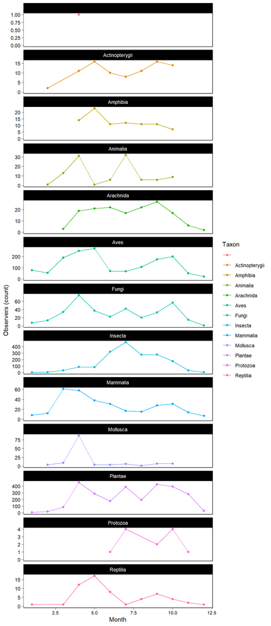

```r
(p.obs <- ggplot() +
  geom_point(data = observations.summary, aes(x = Month, y = Observations, col = Taxon)) +
  geom_line(data = observations.summary, aes(x = Month, y = Observations, col = Taxon)) +
  scale_y_continuous(limits=c(0,NA)) +
  ylab('Observers (count)') + xlab('Month') + facet_wrap(~Taxon, scales = "free_y", ncol = 1) +
  theme_linedraw() + theme(panel.grid = element_blank(), axis.text.x = element_text(size = 8)))
```

```r
png(filename = "C:/Users/Admin/Documents/GitHub/Western-Biodiversity-Inventory_rinat/Figures/Research_grade_observations_xMonth_xTaxon.png",
    res = 300,
    width = 4,
    height = 14,
    units = 'in')
p.obs
```

```
`geom_line()`: Each group consists of only one observation.
ℹ Do you need to adjust the group aesthetic?
```

```r
dev.off()
```

# Most recent species/genus added: top 50

As the iNaturalist webpage doesn’t easily summarize which species / taxa was the most recently added to a project, we can use R to sort the observations by date. Obviously, this can also be done though exporting the data directly to a csv file, but R allows us to do this all at once.

```r
observations %>%
  group_by(scientific_name) %>%
  slice_min(order_by = observed_on) %>%
  arrange(desc(observed_on)) %>%
  dplyr::select(scientific_name, observed_on, user_name) %>%
  data.frame() %>%
  head(50)
```

```
                   scientific_name observed_on            user_name
1                       Mustelidae  2024-02-13        Scousemouse12
2                           Citrus  2023-11-24              Quinn C
3                       Stemonitis  2023-11-24       Jackson Kusack
4               Tricholoma terreum  2023-11-18          Faiza Islam
5                            Fagus  2023-11-15      Brendon Samuels
6                         Pholiota  2023-11-10            Maddie P.
7                  Stereum lobatum  2023-11-10
8      Callirhytis quercuspunctata  2023-11-09
9                       Miscanthus  2023-11-09
10                Grifola frondosa  2023-11-08
11 Gnorimoschema gallaesolidaginis  2023-11-02        Jasmine Bajwa
12                  Salix purpurea  2023-11-02       Madison McGhee
13                Smilax tamnoides  2023-10-28           Greg Thorn
14                Smilax tamnoides  2023-10-28           Greg Thorn
```

[output cut: 36 more lines]

# Most rare species seen on campus:

## 2022-2023 Inventory

```r
observation.counts <- iNat_sc(project_id = 'biodiversity-inventory-at-western', quality_grade = "research", d1 = "2022-04-01", d2 = "2023-03-31")

rarity.df <- observation.counts %>%
  arrange(taxon.observations_count) %>%
  dplyr::select(count, taxon.observations_count, taxon.name, taxon.preferred_common_name) %>%
  rename('total.count' = taxon.observations_count) %>%
  rename('common.name' = taxon.preferred_common_name) %>%
  data.frame()

head(rarity.df, 50)
```

```
   count total.count                   taxon.name                   common.name
1      1          16           Strauzia vittigera                          <NA>
2      1          17           Trepobates inermis                          <NA>
3      1          67             Andrena hippotes       Orange-legged Miner Bee
4      1          71           Anametis granulata                          <NA>
5      2          76          Notropis photogenis                 Silver Shiner
6      1          76          Fomoria pteliaeella      Wafer Ash Leafminer Moth
7      1          98        Arthaldeus pascuellus                          <NA>
8      1         101       Liriomyza eupatoriella                          <NA>
9      1         110    Hemicrepidius decoloratus                          <NA>
10     1         139             Alcathoe caudata       Clematis Clearwing Moth
11     1         147         Microvelia americana                          <NA>
12     1         157      Pediopsoides distinctus                          <NA>
13     1         197             Rhagovelia obesa                          <NA>
14     1         274         Amblysellus curtisii                          <NA>
```

[output cut: 36 more lines]

## All years

```r
observation.counts <- iNat_sc(project_id = 'biodiversity-inventory-at-western', quality_grade = "research")

rarity.df <- observation.counts %>%
  arrange(taxon.observations_count) %>%
  select(count, taxon.observations_count, taxon.name, taxon.preferred_common_name) %>%
  rename('total.count' = taxon.observations_count) %>%
  rename('common.name' = taxon.preferred_common_name) %>%
  data.frame()

head(rarity.df, 50)
```

```
   count total.count                 taxon.name                     common.name
1      1           1      Athyroglossa ordinata                            <NA>
2      2           9   Aureobasidium apocryptum                            <NA>
3      1          16     Pissonotus aphidioides                            <NA>
4      1          16         Strauzia vittigera                            <NA>
5      3          17         Trepobates inermis                            <NA>
6      1          18          Neurigona rubella                            <NA>
7      1          19                Dectes sayi              Soybean Stem Borer
8      1          21            Aulacus burquei                            <NA>
9      1          27         Leptopeza flavipes                            <NA>
10     1          28          Rhaphium melampus                            <NA>
11     2          30       Rheumatobates rileyi                            <NA>
12     1          41          Aethes floccosana                            <NA>
13     1          44             Psila collaris                            <NA>
14     1          54       Bombylius pulchellus                            <NA>
```

[output cut: 36 more lines]

## Rarest

1. Athyroglossa ordinata

https://www.inaturalist.org/observations/159829124

2. Aureobasidium apocryptum

https://www.inaturalist.org/observations/84425767

3. Pissonotus aphidioides

https://www.inaturalist.org/observations/173404749

4. Strauzia vittigera

https://www.inaturalist.org/observations/121285089

5. Trepobates inermis

https://www.inaturalist.org/observations/136089914

# Species accumulation curve: By year

```r
table(lubridate::year(lubridate::as_date(observations$observed_on)))
```

```
1988 1990 1993 2005 2007 2009 2010 2011 2012 2013 2014 2015 2016 2017 2018 2019
   3   10    1    6    1    3    2   12   11   16    3    3    4   37  136 1260
2020 2021 2022 2023 2024
 437 2061 3089 5098   34
```

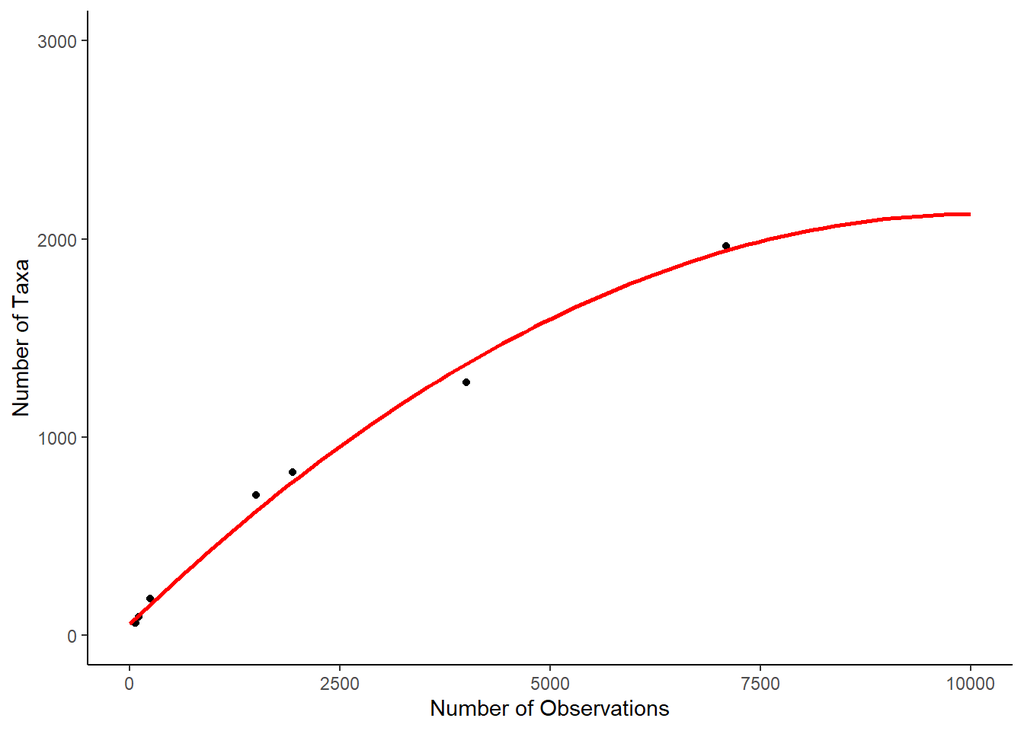

```r
df <- data.frame(rep(0,10),rep(0,10))
names(df) <- c('observations','taxa')

for(i in seq_len(nrow(df))) {

  temp <- observations %>%
    mutate(observed_on = lubridate::as_date(observed_on)) %>%
    filter(observed_on >= lubridate::as_date("1988-01-01") &
             observed_on < lubridate::as_date(paste(2014+i,"-01-01", sep="")))
  df[i,1] <- nrow(temp)
  df[i,2] <- length(unique(temp$taxon_id))
}

print(ggplot(data = df, aes(y = taxa, x = observations)) +
  geom_point() +
  stat_smooth(method = "lm", formula = y ~ poly(x,2), se = FALSE, col = "red", fullrange=TRUE) +
  labs(x = "Number of Observations", y = "Number of Taxa") +
  xlim(0,10000) + ylim(0,3000) +
  theme_classic())
```

# Most observed species that I’m missing

```r
jk.species <- observations %>%
  filter(user_login == 'jacksonkusack') %>%
  select(scientific_name) %>%
  unique()

observation.counts <- iNat_sc(project_id = 'biodiversity-inventory-at-western', quality_grade = "research") %>%
  arrange(desc(count)) %>%
  filter(taxon.iconic_taxon_name != "Aves") %>%
  dplyr::select(count, taxon.name, taxon.preferred_common_name) %>%
  rename('common.name' = taxon.preferred_common_name) %>%
  data.frame()

jk.missing <- observation.counts %>%
  subset(!(taxon.name %in% jk.species$scientific_name))

head(jk.missing, 50)
```

```
    count                  taxon.name                  common.name
43     21           Leonurus cardiaca            common motherwort
45     20         Chelydra serpentina       Common Snapping Turtle
47     20             Cirsium arvense             creeping thistle
55     19          Euonymus europaeus                      Spindle
66     16               Canis latrans                       Coyote
74     15       Maianthemum racemosum              Solomon's plume
78     15         Clematis virginiana               virgin's-bower
79     15            Argiope aurantia         Yellow Garden Spider
82     15           Lasmigona costata                  Flutedshell
83     15           Potentilla indica              mock strawberry
84     14        Juniperus virginiana             eastern redcedar
88     14       Saponaria officinalis              common soapwort
91     14      Symphyotrichum pilosum   hairy white oldfield aster
92     13          Impatiens capensis             common jewelweed
```

[output cut: 36 more lines]

# Code for Peter

## Rare observations (<= 10 ON records)

Pull out species with <= 10 observations within Ontario and check for records of those species in the inventory.

```r
#https://inaturalist.ca/projects/biodiversity-of-ontario

ontario.species <- iNat_sc(project_id = 29563)

ON.10 <- ontario.species %>% # This project is the biodiversity of Ontario - which should give us all of the unique taxa in ON
  filter(count <= 10) # Pull out taxa that have less than or equal to 10 in ON

observations %>% # filter the inventory records that match the taxa above
  filter(scientific_name %in% ON.10$taxon.name) %>%
  dplyr::select(scientific_name, quality_grade) %>%
  filter(quality_grade %in% c("research","needs_id"))
```

```
                  scientific_name quality_grade
1                Ulmus parvifolia      research
2                           Salix      needs_id
3            Melilotus altissimus      research
4               Lentinus flexipes      needs_id
5                  Mycena galopus      needs_id
6    Trigoniophthalmus alternatus      needs_id
7                Aethusa cynapium      needs_id
8                         Lepiota      needs_id
9              Atriplex hortensis      needs_id
10              Ommatius tibialis      research
11          Eutrochium fistulosum      needs_id
12                          Salix      needs_id
13                 Neopachygaster      needs_id
14             Trepobates inermis      research
```

[output cut: 97 more lines]

## Rare observations (<= 5 ON records)

```r
ON.5 <- ontario.species %>% # This project is the biodiversity of Ontario - which should give us all of the unique taxa in ON
  filter(count <= 5) # Pull out taxa that have less than or equal to 10 in ON

observations %>% # filter the inventory records that match the taxa above
  filter(scientific_name %in% ON.5$taxon.name) %>%
  dplyr::select(scientific_name, quality_grade) %>%
  filter(quality_grade %in% c("research","needs_id"))
```

```
                 scientific_name quality_grade
1                          Salix      needs_id
2           Melilotus altissimus      research
3              Lentinus flexipes      needs_id
4                 Mycena galopus      needs_id
5                        Lepiota      needs_id
6             Atriplex hortensis      needs_id
7                          Salix      needs_id
8                 Neopachygaster      needs_id
9             Trepobates inermis      research
10                 Triplax aenea      needs_id
11                Heteromeringia      needs_id
12                         Geron      needs_id
13            Trepobates inermis      research
14         Arhyssus nigristernum      needs_id
```

[output cut: 62 more lines]

## Rare observations (<= 3 ON records)

```r
ON.3 <- ontario.species %>% # This project is the biodiversity of Ontario - which should give us all of the unique taxa in ON
  filter(count <= 3) # Pull out taxa that have less than or equal to 10 in ON

observations %>% # filter the inventory records that match the taxa above
  filter(scientific_name %in% ON.3$taxon.name) %>%
  dplyr::select(scientific_name, quality_grade) %>%
  filter(quality_grade %in% c("research","needs_id"))
```

```
           scientific_name quality_grade
1                    Salix      needs_id
2        Lentinus flexipes      needs_id
3                  Lepiota      needs_id
4                    Salix      needs_id
5           Neopachygaster      needs_id
6       Trepobates inermis      research
7            Triplax aenea      needs_id
8           Heteromeringia      needs_id
9       Trepobates inermis      research
10 Anthopotamus distinctus      needs_id
11           Laphria canis      needs_id
12  Toxorhynchites rutilus      research
13              Sarcophaga      needs_id
14           Laphria canis      needs_id
```

[output cut: 39 more lines]

```r
# Same thing but with middlesex county
middlesex.species <- iNat_sc(project_id = 29563)

middlesex.10 <- middlesex.species %>% # This project is the biodiversity of Ontario - which should give us all of the unique taxa in ON
  filter(count <= 10) # Pull out taxa that have less than or equal to 10 in middlesex

observations %>% # filter the inventory records that match the taxa above
  filter(scientific_name %in% middlesex.10$taxon.name) %>%
  dplyr::select(scientific_name, quality_grade) %>%
  filter(quality_grade %in% c("research","needs_id"))
```

```
                  scientific_name quality_grade
1                Ulmus parvifolia      research
2                           Salix      needs_id
3            Melilotus altissimus      research
4               Lentinus flexipes      needs_id
5                  Mycena galopus      needs_id
6    Trigoniophthalmus alternatus      needs_id
7                Aethusa cynapium      needs_id
8                         Lepiota      needs_id
9              Atriplex hortensis      needs_id
10              Ommatius tibialis      research
11          Eutrochium fistulosum      needs_id
12                          Salix      needs_id
13                 Neopachygaster      needs_id
14             Trepobates inermis      research
```

[output cut: 97 more lines]

## Rare observations (<= 5 ON records)

```r
middlesex.5 <- middlesex.species %>% # This project is the biodiversity of Ontario - which should give us all of the unique taxa in ON
  filter(count <= 5) # Pull out taxa that have less than or equal to 10 in ON

observations %>% # filter the inventory records that match the taxa above
  filter(scientific_name %in% middlesex.5$taxon.name) %>%
  dplyr::select(scientific_name, quality_grade) %>%
  filter(quality_grade %in% c("research","needs_id"))
```

```
                 scientific_name quality_grade
1                          Salix      needs_id
2           Melilotus altissimus      research
3              Lentinus flexipes      needs_id
4                 Mycena galopus      needs_id
5                        Lepiota      needs_id
6             Atriplex hortensis      needs_id
7                          Salix      needs_id
8                 Neopachygaster      needs_id
9             Trepobates inermis      research
10                 Triplax aenea      needs_id
11                Heteromeringia      needs_id
12                         Geron      needs_id
13            Trepobates inermis      research
14         Arhyssus nigristernum      needs_id
```

[output cut: 62 more lines]

## Rare observations (<= 3 ON records)

```r
middlesex.3 <- middlesex.species %>% # This project is the biodiversity of Ontario - which should give us all of the unique taxa in ON
  filter(count <= 3) # Pull out taxa that have less than or equal to 10 in ON

observations %>% # filter the inventory records that match the taxa above
  filter(scientific_name %in% middlesex.3$taxon.name) %>%
  dplyr::select(scientific_name, quality_grade) %>%
  filter(quality_grade %in% c("research","needs_id"))
```

```
           scientific_name quality_grade
1                    Salix      needs_id
2        Lentinus flexipes      needs_id
3                  Lepiota      needs_id
4                    Salix      needs_id
5           Neopachygaster      needs_id
6       Trepobates inermis      research
7            Triplax aenea      needs_id
8           Heteromeringia      needs_id
9       Trepobates inermis      research
10 Anthopotamus distinctus      needs_id
11           Laphria canis      needs_id
12  Toxorhynchites rutilus      research
13              Sarcophaga      needs_id
14           Laphria canis      needs_id
```

[output cut: 39 more lines]

## Middlesex county first firsts

Too determine what the first firsts are for Middlesex, we need to download all the middlesex data (which is going to take a bit of time and too many records to do using ‘get_inat_obs’). Luckily there aren’t more that 200,000 observations, so we can just export the file on the website.

If you want to repeat this, you’ll need to download that file.

```r
observations.middlesex <- read.csv("C:/Users/Admin/Documents/GitHub/Western-Biodiversity-Inventory_rinat/Data/observation_middlesex.csv")

# First firsts for middlesex county (within the timeframe of the survey)
first.firsts.middlesex <- observations.middlesex %>%
  group_by(scientific_name) %>%
  slice_min(order_by = observed_on) %>%
  mutate(date = as_date(observed_on)) %>%
  arrange(desc(date)) %>%
  dplyr::select(scientific_name, date, user_name, id) %>%
  data.frame() %>%
  filter(date >= as_date("2022-04-01"),
         date <= as_date("2023-03-31"))
```

Once we have the first firsts for middlesex county - we just need to use those ID’s to see which of them were seen within the inventory (see below).

```r
observations[observations$id %in% unique(first.firsts.middlesex$id),] %>%
  dplyr::select(scientific_name, quality_grade, id, observed_on) %>%
  filter(quality_grade %in% c("research","needs_id"))
```

```
                          scientific_name quality_grade        id observed_on
1                              Ochrophyta      needs_id 142224893  2022-11-10
2                         Acleris maccana      needs_id 141254882  2022-11-06
3               Sericomyia chrysotoxoides      research 141169535  2022-11-05
4                   Arthaldeus pascuellus      research 141169521  2022-11-05
5                        Abagrotis cupida      needs_id 140019990  2022-10-25
6                           Trichia varia      needs_id 140008225  2022-10-25
7              Jackrogersella multiformis      needs_id 140006864  2022-10-25
8                      Platnickina tincta      research 140002040  2022-10-25
9                   Perenniporia ohiensis      needs_id 139789736  2022-10-23
10                    Fomoria pteliaeella      research 139787280  2022-10-23
11                               Naididae      needs_id 139153969  2022-10-17
12                       Rhagovelia obesa      research 139153802  2022-10-17
13                      Papaipema furcata      research 137866382  2022-10-07
14                           Pachytychius      needs_id 137732501  2022-10-05
```

[output cut: 145 more lines]